# Análisis de los supuestos

Luis Fernando Apáez Álvarez

7/11/2021

Supuesto de linealidad

descripción del `summary`

Interpretación de los coeficientes

## Ejercicio

Algunos grupos madereros, silvicultores y biólogos están interesados en poder predecir el volumen de un árbol con sólo conocer su diámetro. Para ello se cuentan con 70 observaciones en la base de datos `shortleaf` donde se tienen dos variables: el diámetro en pulgadas (`Diam`) y el volumen en pies cúbicos (`Vol`). Verifique si puede ajustarse un modelo de regresión lineal simple e interprete los coeficientes.

Primero importamos los datos.

```r
#Cargamos los datos y vemos rapidamente su estructura

datos<- read.table("shortleaf.txt", header = T)
head(datos)
```

```
##   Diam Vol
## 1  4.4 2.0
## 2  4.6 2.2
## 3  5.0 3.0
## 4  5.1 4.3
## 5  5.1 3.0
## 6  5.2 2.9
```

Notamos que tenemos dos variables de tipo numérico y 70 observaciones

```r
str(datos)
```

```
## 'data.frame':    70 obs. of  2 variables:
##  $ Diam: num  4.4 4.6 5 5.1 5.1 5.2 5.2 5.5 5.5 5.6 ...
##  $ Vol : num  2 2.2 3 4.3 3 2.9 3.5 3.4 5 7.2 ...
```

Notamos que la variable independiente es `Diam` y la dependiente es `Vol`.

## Supesto de linealidad

Comenzamos graficando un scatterplot:

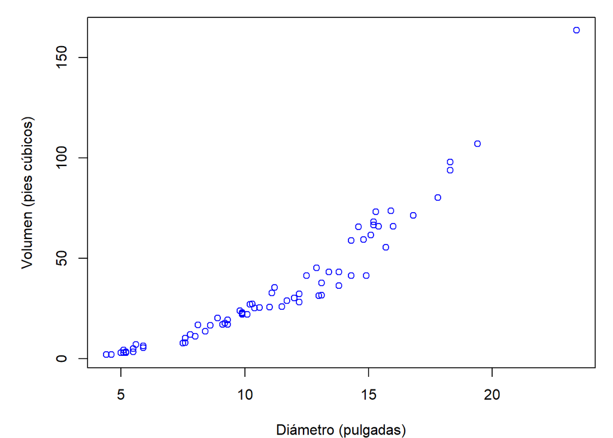

```r
par(mar=c(4, 5, 1, 1))
plot(datos$Diam, datos$Vol, xlab="Diámetro (pulgadas)", ylab="Volumen (pies cúbicos)",col="blue")
```

o alternativamente

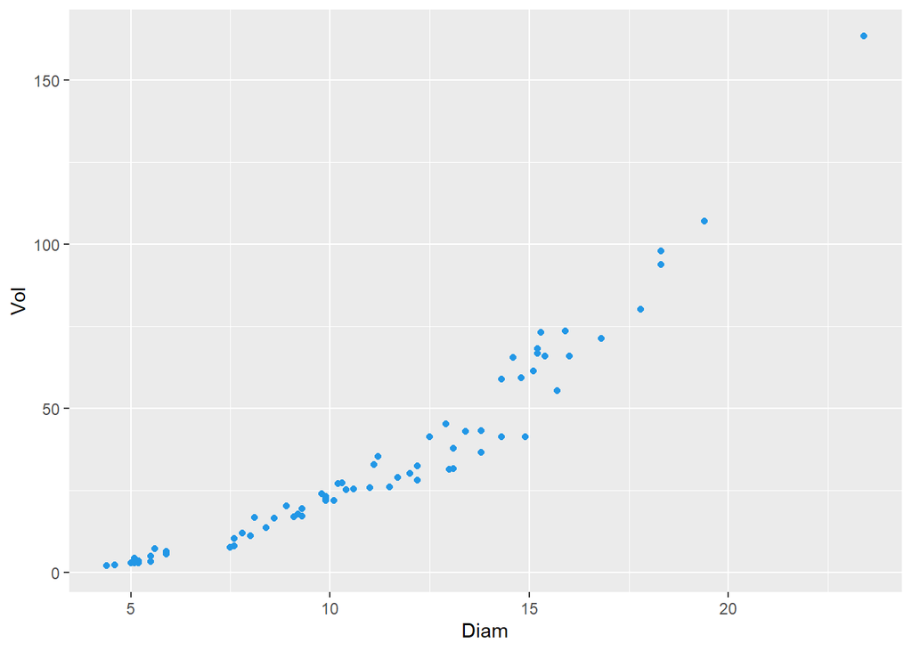

```r
# Cargamos la librería necesaria
library(ggplot2)

#graficamos
ggplot(datos, aes(x=Diam, y=Vol)) +
  geom_point(colour=4)
```

Aparentemente podemos ver que no se cumple el supuesto de linealidad, pero ajustaremos la regresión lineal sobre estos datos para hacerlo más notorio

```r
#Ajustamos el modelo
fit1 <- lm(Vol~Diam, data=datos)

# Mostramos los valores de b0 y b1
fit1$coefficients
```

```
## (Intercept)        Diam
##  -41.568090    6.836718
```

Después graficamos la línea de ajuste en el diagrama de dispersión:

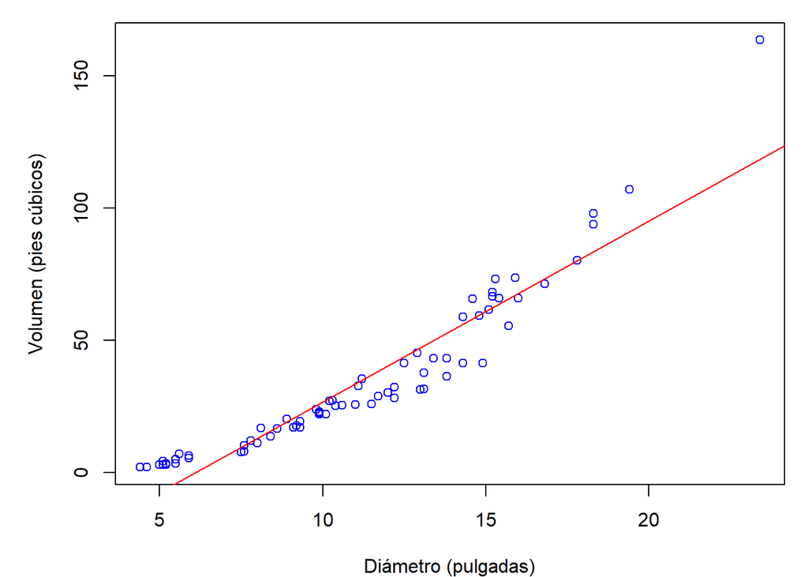

```r
par(mar=c(4, 5, 1, 1))
plot(datos$Diam, datos$Vol, xlab="Diámetro (pulgadas)", ylab="Volumen (pies cúbicos)",col="blue")

# Agregamos la línea

abline(fit1$coefficients, col="red")
```

Más aún podemos utilizar la gráfica que nos brinda `R` para analizar el supuesto de la linealidad

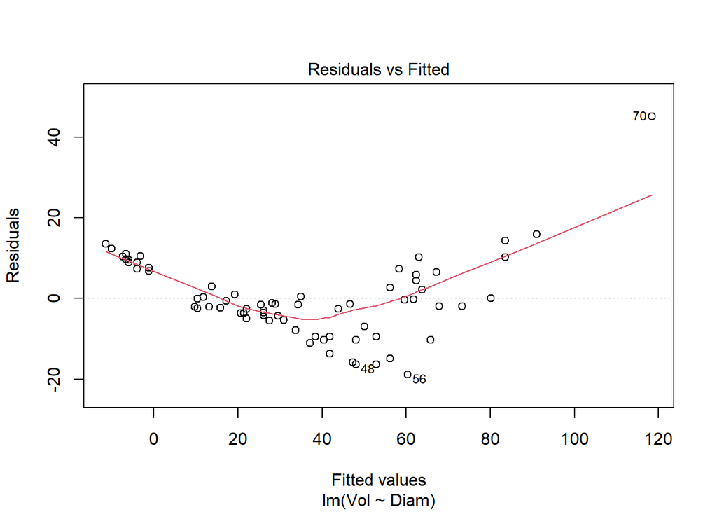

```r
plot(fit1, 1)
```

lo cual nos corroborá que este supuesto no se cumple pues nos gustaría que la línea roja estuviera muy cerca de la recta en 0. También, podemos checar rápidamente el supuesto de la homocedasticidad

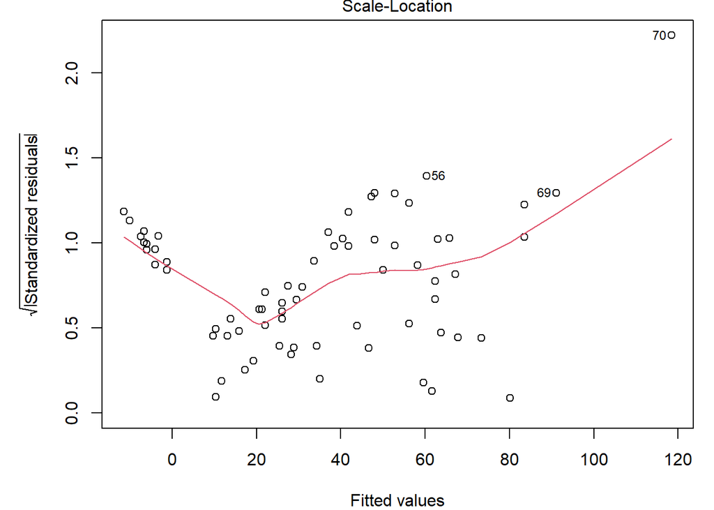

```r
par(mar=c(4, 5, 1, 1))
plot(fit1, 3)
```

el cual también no se cumple. Por lo anterior, debemos de encontrar un mejor modelo transformando nuestros datos.

Luego, utilizaremos la transformación logarítmica para hacer que los supuestos se cumplan, donde se sabe que la transformación que funciona es esa pues ya se probó (para los fines de esta práctica usamos directo dicha transformación, pero para saber qué transformación usar están las transformaciones de tipo Box-Cox o Box-Tidwell).

```r
#Creamos nuestras variables transformadas y las guardamos en el dataframe.
datos$lnDiam=log(datos$Diam)
datos$lnVol=log(datos$Vol)

#Ajustamos un modelo pero con los datos transformados.
fit2 <- lm(lnVol ~ lnDiam, data = datos)
fit2$coefficients
```

```
## (Intercept)      lnDiam
##   -2.871790    2.564416
```

Después, comparamos las gráficas de los dos modelos obtenidos, es decir, la gráfica con los datos no transformados versus la gráfica con los datos transformados

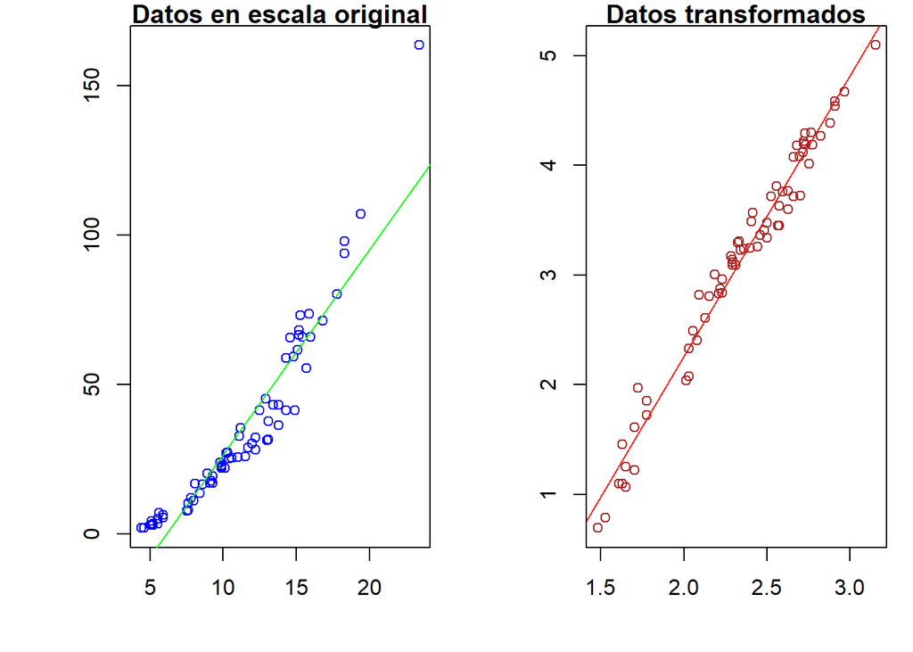

```r
par(mfrow=c(1,2))
par(mar=c(4, 5, 1, 1))

# Gráfica datos no transformados
plot(datos$Diam, datos$Vol, main="Datos en escala original",xlab="", ylab="",col="blue")
abline(fit1$coefficients, col="green")

# Gráfica datos transformados
plot(datos$lnDiam, datos$lnVol, main="Datos transformados",xlab="", ylab="", col="brown")
abline(fit2$coefficients, col="red")
```

Checamos ahora los supuestos de linealidad y homocedasticidad con el modelo ajustado con los datos transformados

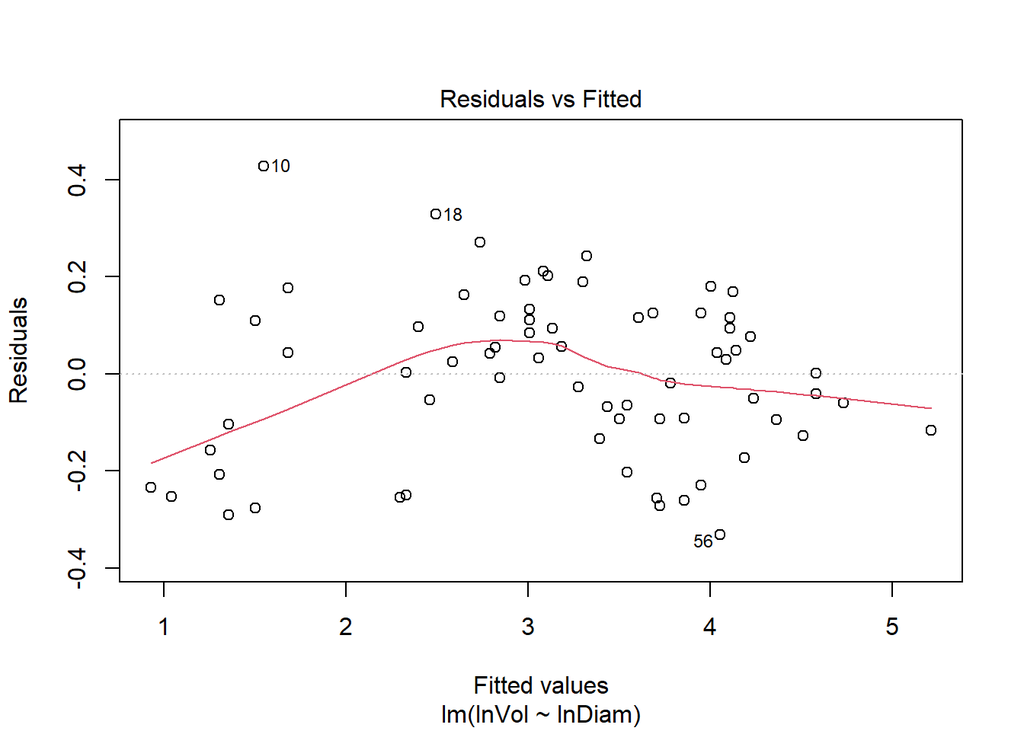

```r
# Linealidad

plot(fit2, 1)
```

luego

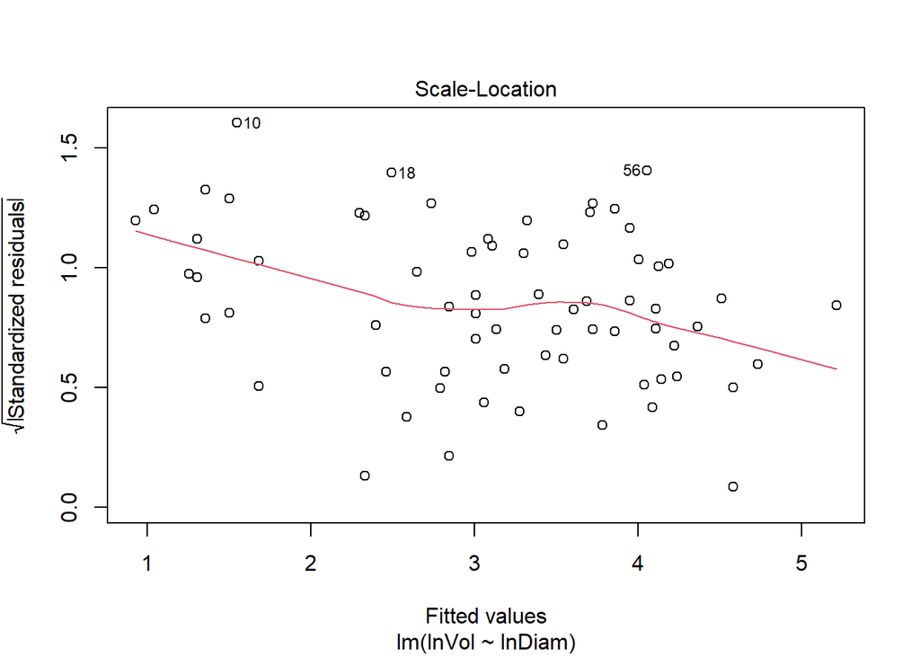

```r
# homocedasticidad

plot(fit2, 3)
```

concluyendo que es mejor trabajar con los datos transformados.

## Descripción del `summary`

Considerando que

```r
summary(fit2)
```

```
##
## Call:
## lm(formula = lnVol ~ lnDiam, data = datos)
##
## Residuals:
##     Min      1Q  Median      3Q     Max
## -0.3323 -0.1131  0.0267  0.1177  0.4280
##
## Coefficients:
##             Estimate Std. Error t value Pr(>|t|)
## (Intercept)  -2.8718     0.1216  -23.63   <2e-16 ***
## lnDiam        2.5644     0.0512   50.09   <2e-16 ***
## ---
## Signif. codes:  0 '***' 0.001 '**' 0.01 '*' 0.05 '.' 0.1 ' ' 1
##
## Residual standard error: 0.1703 on 68 degrees of freedom
## Multiple R-squared:  0.9736, Adjusted R-squared:  0.9732
## F-statistic:  2509 on 1 and 68 DF,  p-value: < 2.2e-16
```

tenemos que

- *Coefficients*: encontramos los valores estimados de $\hat{\beta_{0}}$ y $\hat{\beta_{1}}$, además de $\sqrt{\hat{V}(\hat{\beta_{0}})}$ y $\sqrt{\hat{V}(\hat{\beta_{1}})}$ en la columna *Std.error*.
- *Coefficients*: también, encontramos los valores de las estadísticas $t$ asociadas a las pruebas de hipótesis

  $$H_{0}: \beta_{0} \ \ vs\ \ H_{a}: \beta_{0}\neq0$$

  y

  $$H_{0}: \beta_{1} \ \ vs\ \ H_{a}: \beta_{1}\neq0$$
  y los_p-values_ correspondientes.
- En el último apartado nos arroja los valores de $\hat{\sigma}$, el coeficiente de determinación $R^{2}$ y los resultados asociados a la prueba $F$ de la tabla anova.

## Interpretación de los coeficientes

- Para $\hat{\beta_{1}}$: Por cada unidad log(pulgada) adicional al diámetro de un árbol, el número promedio de log(pies cúbicos) de volumen de un árbol aumenta 2.5644.
- Para $\hat{\beta_{0}}$: Para 0 unidades de log(pulgadas) del diámetro de un árbol en promedio se tienen -2.87 log(pies cúbicos) de volumen.

Notamos que tenemos un modelo multiplicativo, por lo que nos conviene tomar el cociente en lugar de la diferencia para llevar a cabo la interpretación . Es decir, si consideramos un aumento proporcional en $\alpha$ unidades al diámetro tenemos

$$\frac{Med(Y;\alpha Diam)}{Med(Y;Diam)}=\alpha^{2.56}=\alpha^{\hat{\beta_{1}}}$$

Si $\alpha=2$, por ejemplo, entonces $\alpha^{2.56}\approx 5.92$ por que se puede interpretar en la escala original que: al aumentar dos veces el diámetro de un árbol la mediana estimada del volumen del volumen cambia en un factor de 5.92. Por ejemplo, la mediana del volumen de un árbol de 20 pulgadas de diámetro, se estima que sea 5.92 veces más grande que la mediana del volumen de un árbol de 10 pulgadas de diámetro.

Finalmente, podemos graficar nuestros datos no transformados y ajustarle una curva asociada a la recta ajustada:

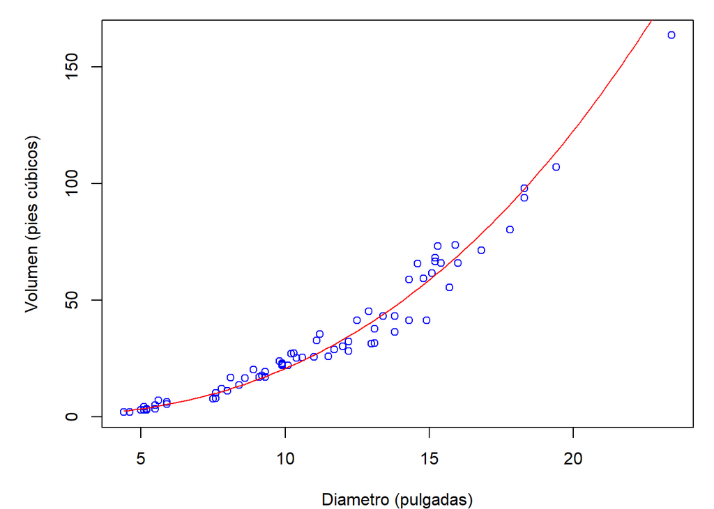

```r
# Gráfico datos no transformados
par(mar=c(4, 5, 1, 1))
plot(datos$Diam, datos$Vol, xlab="Diametro (pulgadas)", ylab="Volumen (pies cúbicos)",
col="blue")

# función para crear la curva
f<- function(diam)
{exp(fit2$coefficients[1])*diam**{fit2$coefficients[2]}}

# Graficamos la curva
curve(f, from=min(datos$Diam), to = max(datos$Diam), col="red", add=T)
```

donde `fit2$coefficients[1]` es $\hat{\beta_{0}}$ y `fit2$coefficients[2]` es $\hat{\beta_{1}}$.